# Simple document

Legend YAML header: The segment at the beginning of the document bracketed by —s. Text + inline R: Written text with simple formatting like # heading, **bold**, and *italic* Code chunks: Blocks of code surrounded by ```

I’m an R Markdown document!

# Section 1

Here’s a **code chunk** that samples from a *normal distribution*:

Use option+command+i for codes {r}

```r
#This is a comment, but usually there is no need for this setup.
samp = rnorm(100)
length(samp)
```

[output not shown]

# Section 2

I can take the mean of the sample, too! The mean is 0.08.

Rounding function is round(mean(samp), decimal places)

# Section 3

this is going to make a plot

```r
plot_df =
  tibble(
    x = rnorm(n = 1000),
    y = 1 + 2*x^2 + rnorm(n = 1000)
  )
plot_df
```

```
## # A tibble: 1,000 × 2
##           x      y
##       <dbl>  <dbl>
##  1  0.960    2.96
##  2 -1.47     3.90
##  3  0.119   -0.647
##  4  1.11     2.08
##  5  0.277    1.09
##  6  1.44     4.21
##  7 -1.17     3.88
##  8  0.00444  1.87
##  9 -1.11     3.14
## 10 -0.975    5.13
## # … with 990 more rows
```

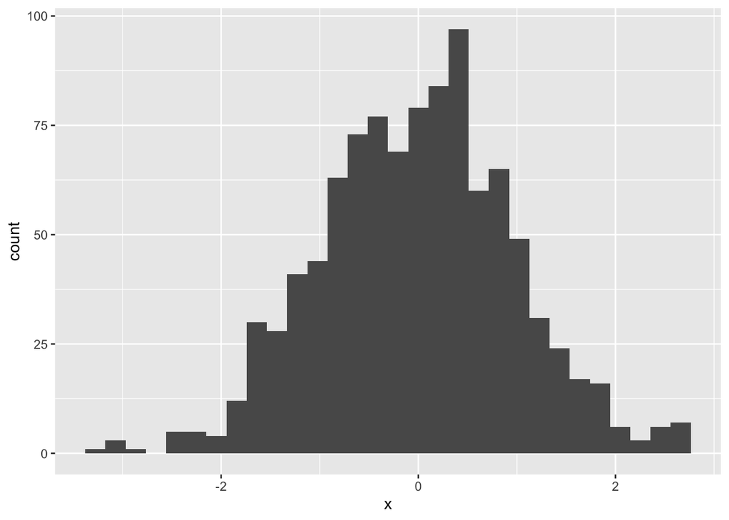

```r
ggplot(plot_df, aes(x = x)) + geom_histogram()
```

```r
gpp = ggplot(plot_df,aes(x = x, y = y)) + geom_point()

ggsave("scatter_plot.pdf", heigh = 4, width = 6)
```

# Section 4

Learning assessment: Write a named code chunk that creates a dataframe comprised of: a numeric variable containing a random sample of size 500 from a normal variable with mean 1; a logical vector indicating whether each sampled value is greater than zero; and a numeric vector containing the absolute value of each element. Then, produce a histogram of the absolute value variable just created. Add an inline summary giving the median value rounded to two decimal places. What happens if you set eval = FALSE to the code chunk? What about echo = FALSE

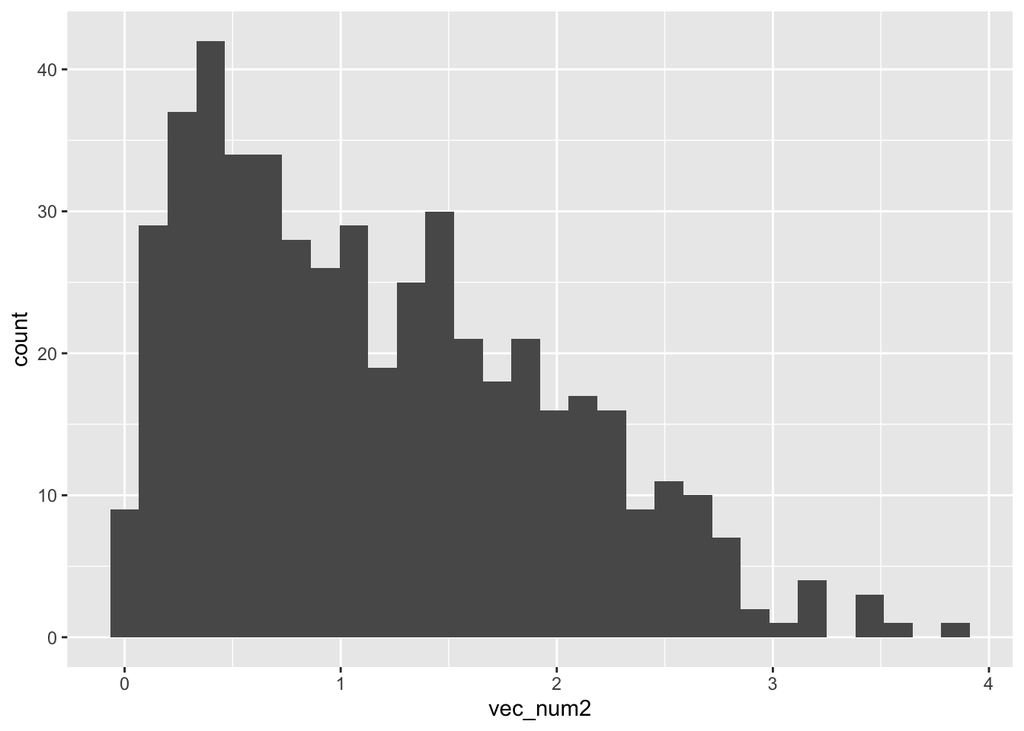

```r
example_df = #need to fill the entire dataframe -- 5:18 wouldn't work bc 10 empty rows
    tibble( #tibble is a function
      vec_numeric = rnorm(n = 500, mean = 1),
      vec_logical = vec_numeric > 0,
      vec_num2 = abs(vec_numeric),
    )
ggplot(example_df, aes(x = vec_num2)) + geom_histogram()
```

```r
round(median(pull(example_df, vec_num2)), 2)
```

```
## [1] 1.08
```

- list item 1
- list item 2

| First header | second header |
| --- | --- |
| content 1 | content 1 |
| content 2 | content 2 |

- list 1